# Projekt

Zuzanna Kozyra, Michał Łysakowski

2024-01-23

## Dane

Dane zostały pobrane z yahoo. Dotyczą cen bitcoina i etherium w dolarach od 2020-01-01 do 2023-12-31.

```r
library(tseries)
library(knitr)
library(tidyverse)
library(moments)
library(lmtest)
library(forecast)
library(nortest)

BTC <- get.hist.quote(instrument = "BTC-USD", start = "2020-01-01",
                             end = "2023-12-31", quote = "Close", provider = "yahoo")
ETH <- get.hist.quote(instrument = "ETH-USD", start = "2020-01-01",
                             end = "2023-12-31", quote = "Close", provider = "yahoo")

kable(head(BTC))
```

| Close |
| --- |
| 7200.174 |
| 6985.470 |
| 7344.884 |
| 7410.657 |
| 7411.317 |
| 7769.219 |

```r
kable(head(ETH))
```

| Close |
| --- |
| 130.8020 |
| 127.4102 |
| 134.1717 |
| 135.0694 |
| 136.2768 |
| 144.3042 |

## Braki danych

```r
sum(is.na(BTC))
```

```
## [1] 0
```

```r
sum(is.na(ETH))
```

```
## [1] 0
```

Nie ma braków danych.

## Podstawowe statystyki opisowe

```r
btc_summary <- summary(BTC)
kable(data.frame("BTC" = btc_summary[,2]))
```

| BTC |
| --- |
| Min. : 4971 |
| 1st Qu.:16967 |
| Median :27307 |
| Mean :28890 |
| 3rd Qu.:39774 |
| Max. :67567 |

```r
eth_summary <- summary(ETH)
kable(data.frame("ETH" = eth_summary[,2]))
```

| ETH |
| --- |
| Min. : 110.6 |
| 1st Qu.: 737.8 |
| Median :1677.8 |
| Mean :1716.1 |
| 3rd Qu.:2274.5 |
| Max. :4812.1 |

## Normalność danych

$H_0$: dane mają rozkład normalny

```r
btc_lillie <- lillie.test(BTC)
eth_lillie <- lillie.test(ETH)
btc_ad <- ad.test(BTC)
eth_ad <- ad.test(ETH)

normality <- matrix(c(btc_lillie$p.value, eth_lillie$p.value, btc_ad$p.value, eth_ad$p.value), ncol = 2, byrow = T)
normality <- data.frame(normality)
colnames(normality) <- c("BTC", "ETH")
rownames(normality) <- c("Lilliefors", "Anderson - Darling")
kable(normality, digits = c(100, 100))
```

|  | BTC | ETH |
| --- | --- | --- |
| Lilliefors | 0.0e+00 | 0.0e+00 |
| Anderson - Darling | 3.7e-24 | 3.7e-24 |

Na podstawie testów Lillieforsa i Andersona - Darlinga odrzucamy hipotezę zerową o normalności zmiennych `BTC` i `ETH`. zmienne mają rozkład inny niż normalny.

## Skośność i kurtoza

```r
btc_skew <- skewness(BTC)
eth_skew <- skewness(ETH)
btc_kurt <- kurtosis(BTC)
eth_kurt <- kurtosis(ETH)

skew_kurt <- matrix(c(btc_kurt, eth_kurt, btc_skew, eth_skew), ncol = 2, byrow = T)
skew_kurt <- data.frame(skew_kurt)
colnames(skew_kurt) <- c("BTC", "ETH")
rownames(skew_kurt) <- c("Kurtoza", "Skośność")
kable(skew_kurt)
```

|  | BTC | ETH |
| --- | --- | --- |
| Kurtoza | 2.2891359 | 2.7441616 |
| Skośność | 0.4062575 | 0.4786215 |

Obydwie zmienne mają współczynnik asymetrii większy od zera, więc mają rozkład asymetryczny o asymetrii prawostronnej - dominują jednostki w zbiorowosci o wartościach cechy niższych od średniej arytmetycznej.

Współczynnik koncentracji obydwu zmiennych jest mniejszy od trzech, więc ich rozkład jest spłaszczony, tzn. koncentracja jednostek zbiorowości pod względem badanej cechy wokół średniej jest słabsza od rozkładu normalnego.

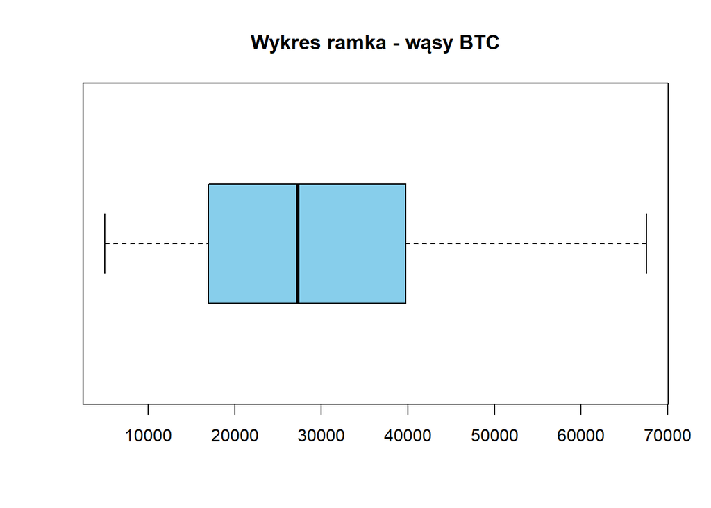

```r
boxplot(BTC, col = "skyblue", main = "Wykres ramka - wąsy BTC", horizontal = TRUE)
```

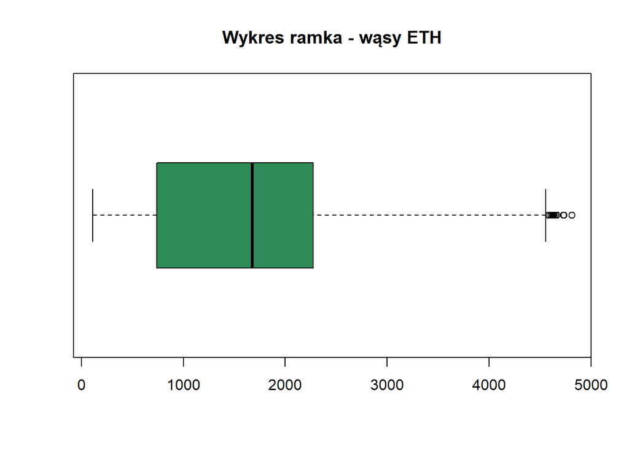

```r
boxplot(ETH, col = "seagreen", main = "Wykres ramka - wąsy ETH", horizontal = TRUE)
```

Histogramy

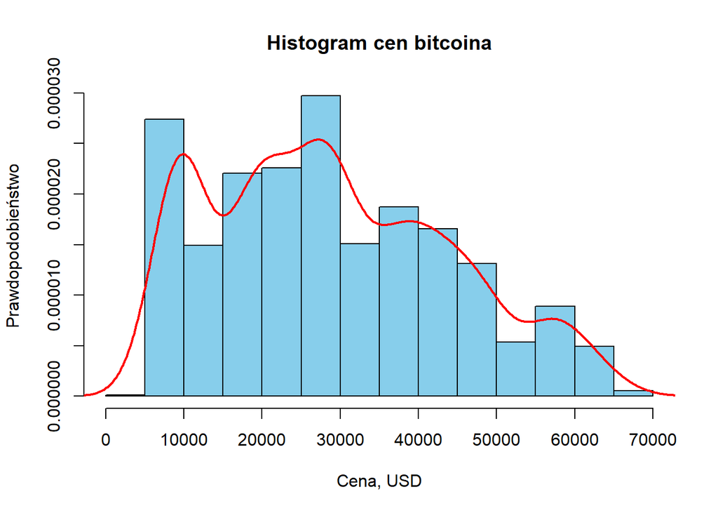

```r
options(scipen = 10)
hist(BTC, col = "skyblue", xlab = "Cena, USD", ylab = "Prawdopodobieństwo", main = "Histogram cen bitcoina", prob=TRUE)
gestosc <- density(BTC)
lines(x=gestosc$x, y=gestosc$y, col="red", lwd=2)
```

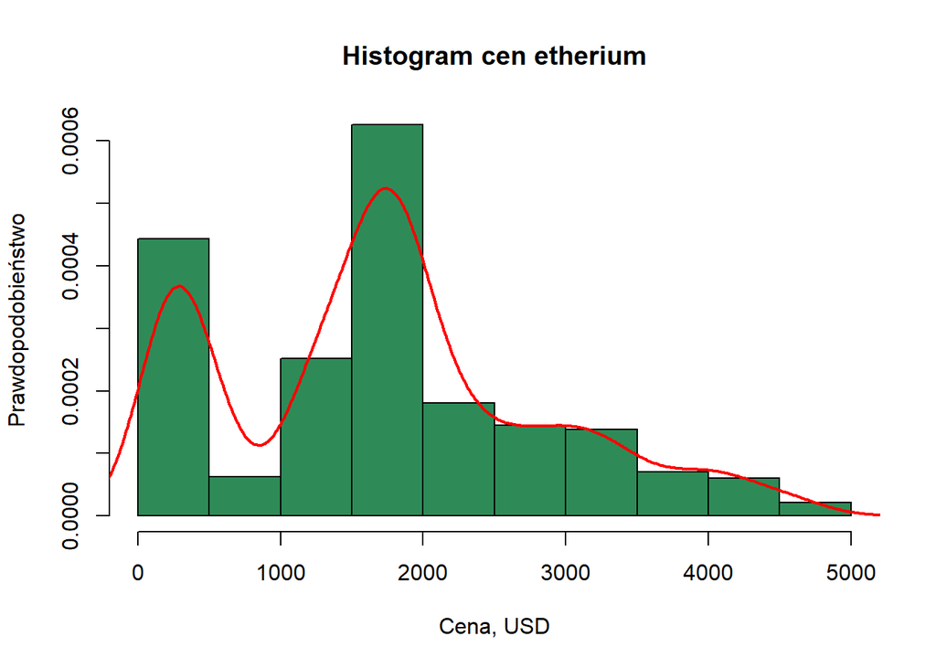

```r
options(scipen = 10)
hist(ETH, col = "seagreen", xlab = "Cena, USD", ylab = "Prawdopodobieństwo", main = "Histogram cen etherium", prob=TRUE)
gestosc <- density(ETH)
lines(x=gestosc$x, y=gestosc$y, col="red", lwd=2)
```

## Różnice

```r
cenaBTC <- BTC$Close
cenaETH <- ETH$Close
```

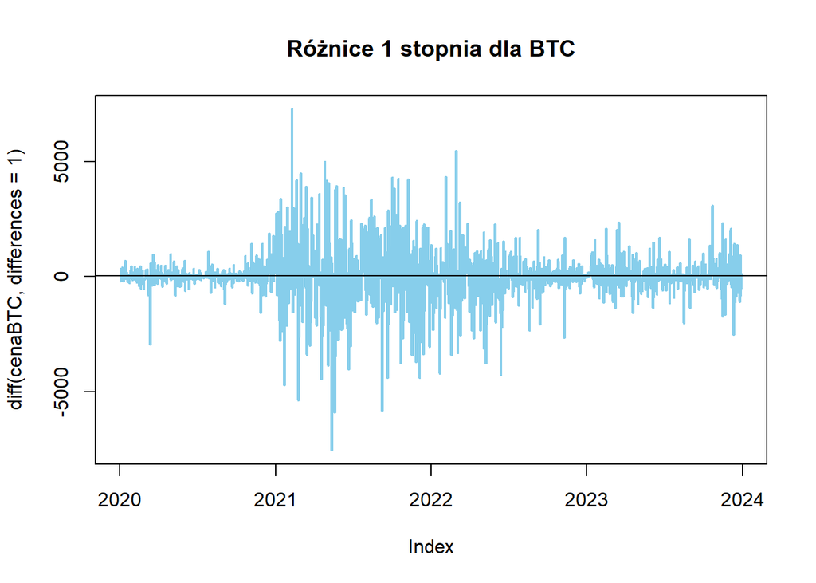

```r
plot(diff(cenaBTC,differences = 1),main = 'Różnice 1 stopnia dla BTC',
     col="skyblue",type='l',lwd=2)
abline(h=mean(diff(cenaBTC,differences=1)),col=1)
```

Na podstawie różnic pierwszego stopnia dla `BTC` widać, że na wraz z początkiem pandemii w 2020 roku ceny bitcoina spadły. Między rokiem 2021 a 2023 widoczne są duże wahania cen, które nastęnie się stabilizują.

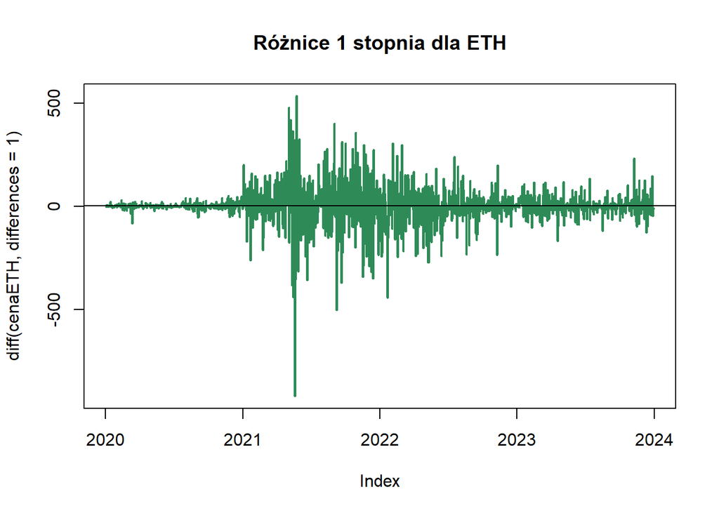

```r
plot(diff(cenaETH,differences = 1),main = 'Różnice 1 stopnia dla ETH',
     col="seagreen",type='l',lwd=2)
abline(h=mean(diff(cenaETH,differences=1)),col=1)
```

Dla zmiennej `ETH` również między rokiem 2021 a 2023 widoczne są duże wahania cen.

## Dopasowanie funkcji wielomianem stopnia od pierwszego do szóstego

```r
wynik <- function(szereg, stopien){
  t <- 1:length(szereg)
  macierz <- NULL
  for(i in 1:stopien){
    macierz <- cbind(macierz, t^i)}

  ramka <- data.frame(szereg, macierz)
  model <- lm(szereg~., data=ramka)
  par(mfrow=c(1,3))
  plot(t, szereg, type="l",
       main=paste("Dopasowanie wiel. st.:", stopien),
       ylab="USD", xlab="notowania")
  lines(t, model$fitted.values, col=2, lwd=1.5)

  plot(t, model$residuals, main="reszty", type="l")
  abline(h=0, col=2, lwd=2)

  plot(ecdf(model$residuals), main="dystrybuanta")
  x <- seq(from=min(model$residuals), to=max(model$residuals), length.out=500)
  lines(x, pnorm(x, mean=0, sd=sd(model$residuals)), col=4,  lwd=2)
  par(mfrow=c(1,1))

  return(AIC(model))}
```

```r
aic <- NULL
for (j in 1:6) {
  aic <- c(aic, wynik(cenaBTC, j))
}
```

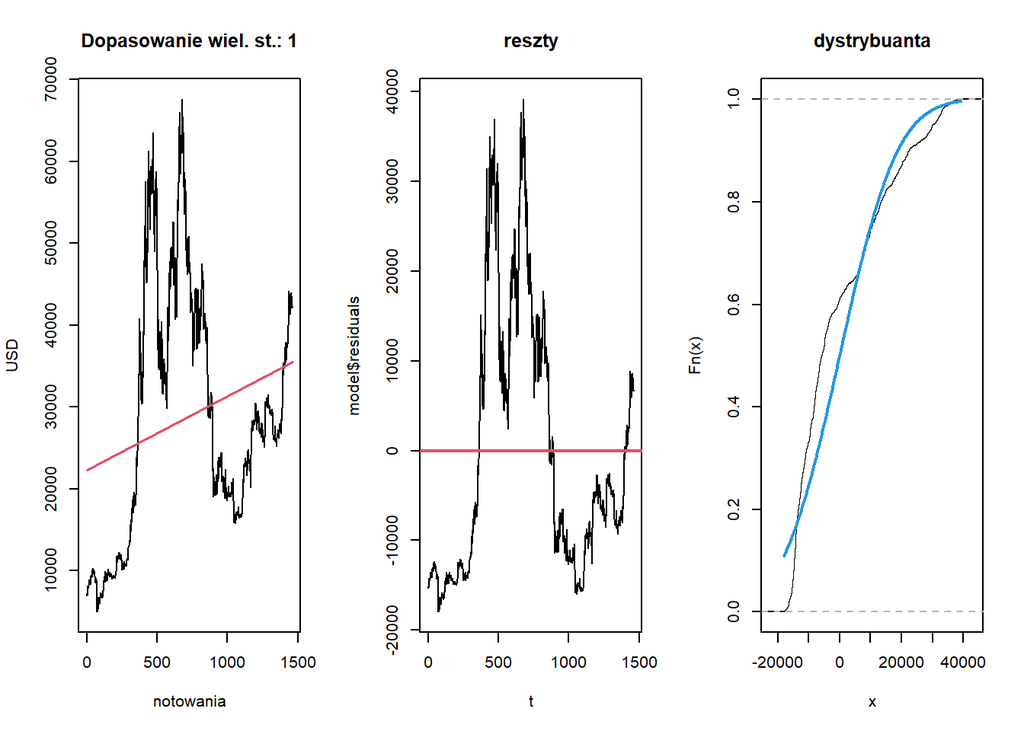

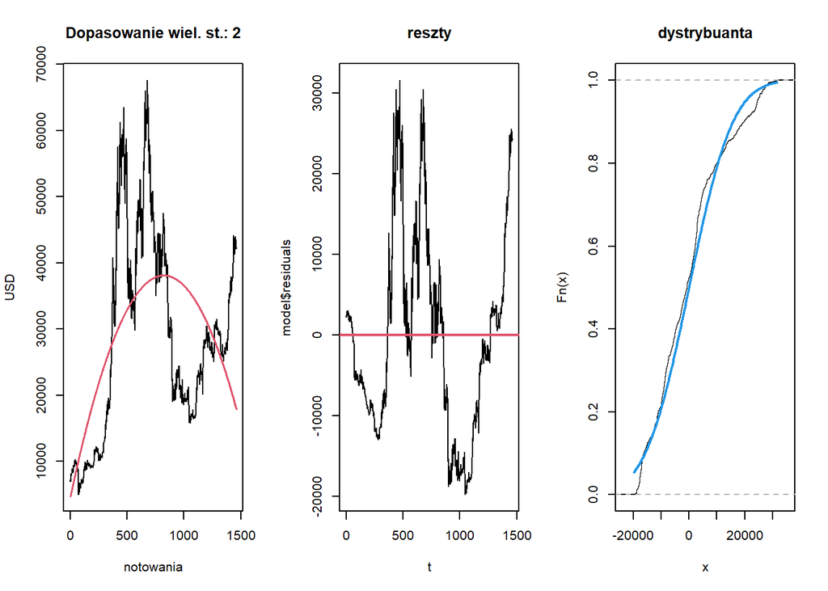

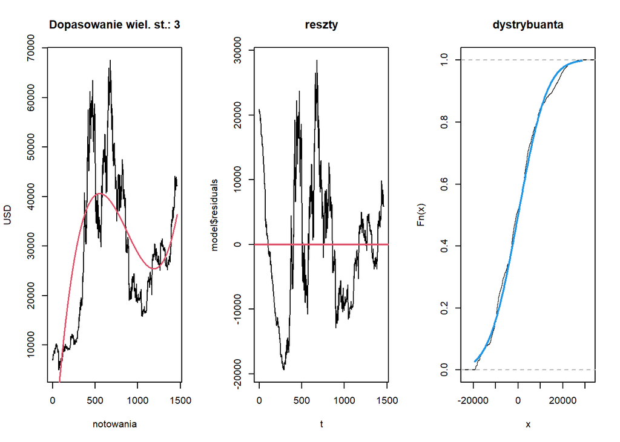

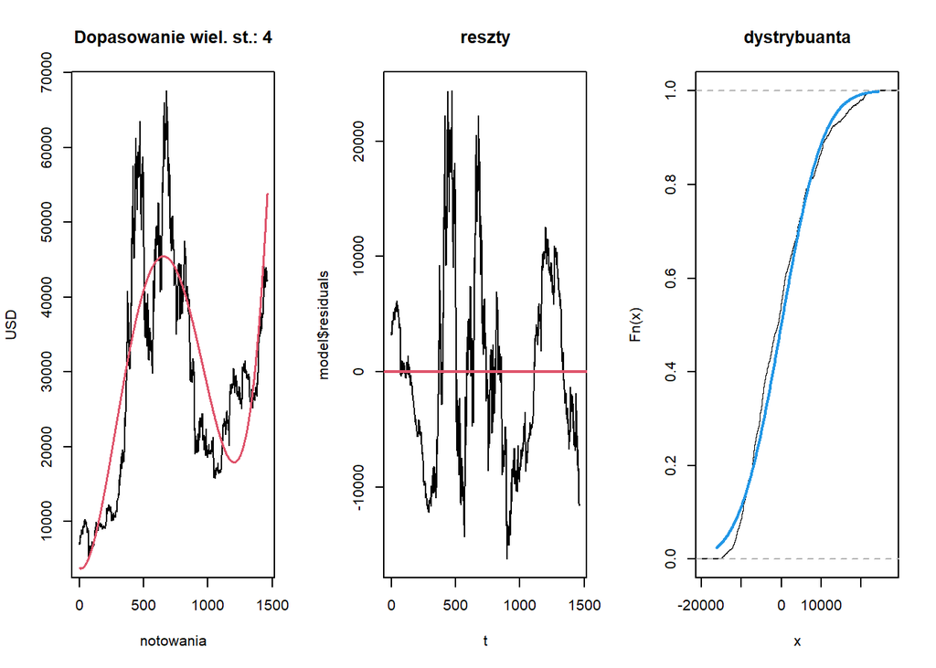

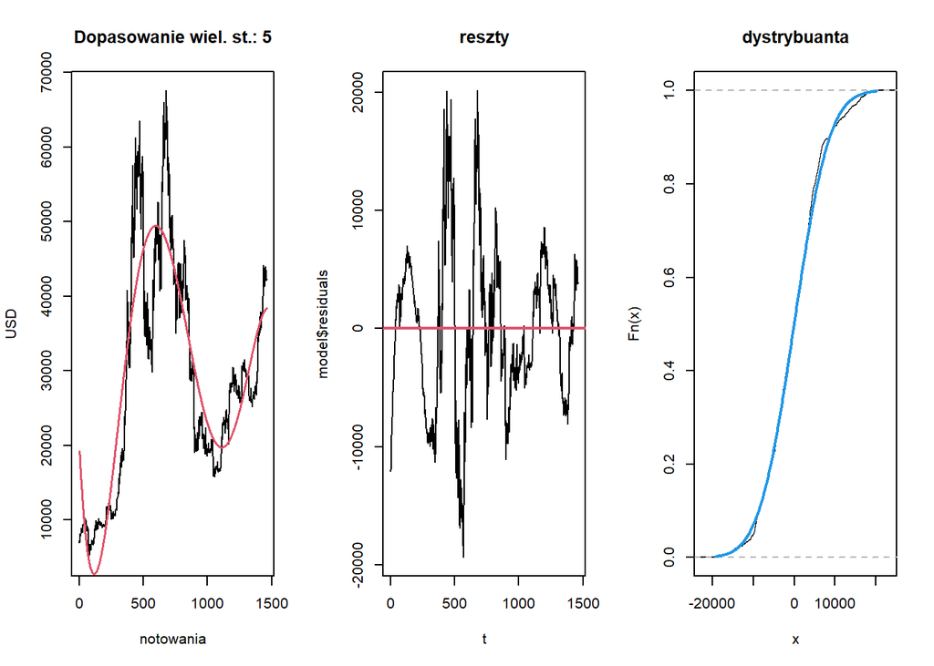

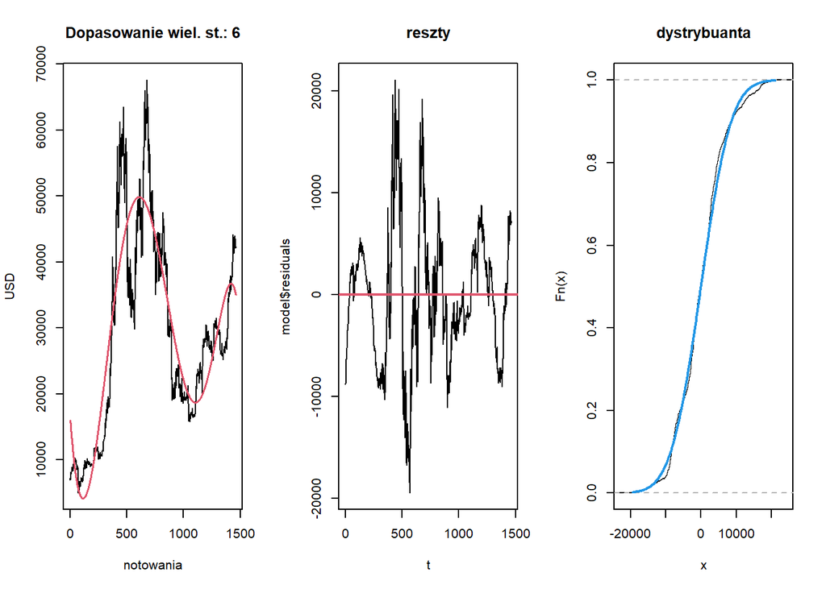

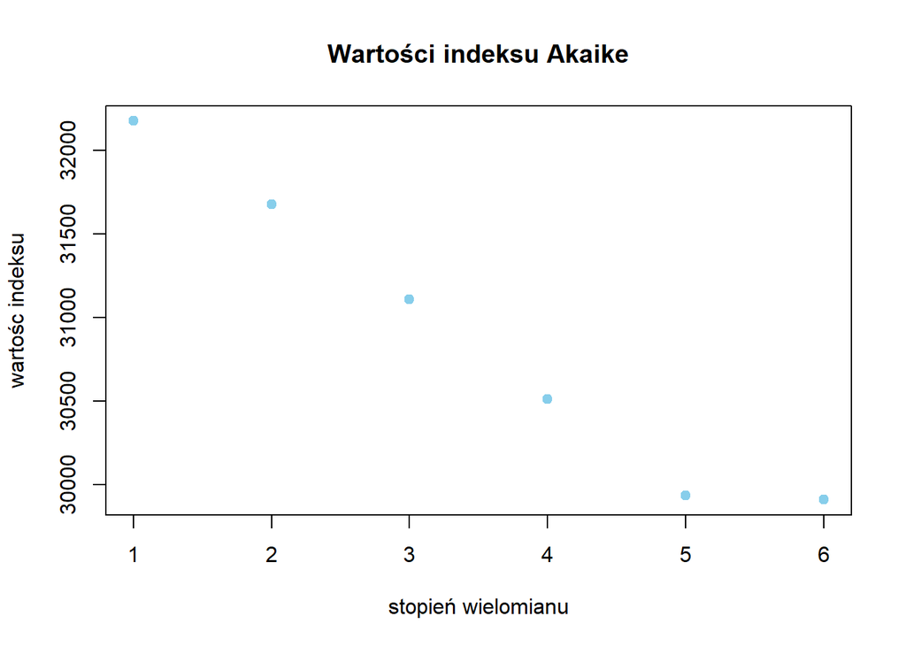

```r
i=1:6
plot(i, aic, type="p", pch=19, main="Wartości indeksu Akaike",
     xlab="stopień wielomianu", ylab = "wartośc indeksu", col = "skyblue")
```

## Modelowanie wielomianem stopnia 5

```r
t_btc <- 1 : length(BTC)
t_eth <- 1 : length(ETH)

mod_btc5 <- lm(BTC ~ t_btc +I(t_btc^2)+I(t_btc^3)+I(t_btc^4) + I(t_btc^5))
mod_eth5 <- lm(ETH ~ t_btc +I(t_btc^2)+I(t_btc^3)+I(t_btc^4) + I(t_btc^5))

summary(mod_btc5)
```

```
##
## Call:
## lm(formula = BTC ~ t_btc + I(t_btc^2) + I(t_btc^3) + I(t_btc^4) +
##     I(t_btc^5))
##
## Residuals:
##    Min     1Q Median     3Q    Max
## -19374  -4369     31   4049  20153
##
## Coefficients:
##                         Estimate           Std. Error t value Pr(>|t|)
## (Intercept) 19593.29620046525451  1073.23165180356364   18.26   <2e-16 ***
## t_btc        -330.99672284286686    14.81606936369286  -22.34   <2e-16 ***
## I(t_btc^2)      1.97803805050217     0.06274510627752   31.52   <2e-16 ***
## I(t_btc^3)     -0.00348776736473     0.00010877335217  -32.06   <2e-16 ***
## I(t_btc^4)      0.00000243664947     0.00000008200762   29.71   <2e-16 ***
## I(t_btc^5)     -0.00000000059263     0.00000000002232  -26.55   <2e-16 ***
## ---
## Signif. codes:  0 '***' 0.001 '**' 0.01 '*' 0.05 '.' 0.1 ' ' 1
##
## Residual standard error: 6796 on 1455 degrees of freedom
## Multiple R-squared:  0.7985, Adjusted R-squared:  0.7978
## F-statistic:  1153 on 5 and 1455 DF,  p-value: < 2.2e-16
```

Wszystkie zmienne w modelu są istotne statystycznie. Model wyjaśnia około $80\%$ zmienności zmiennej `BTC`.

```r
summary(mod_eth5)
```

```
##
## Call:
## lm(formula = ETH ~ t_btc + I(t_btc^2) + I(t_btc^3) + I(t_btc^4) +
##     I(t_btc^5))
##
## Residuals:
##      Min       1Q   Median       3Q      Max
## -1277.77  -364.91   -22.94   330.97  1732.64
##
## Coefficients:
##                         Estimate           Std. Error t value Pr(>|t|)
## (Intercept) 1209.258902216139631   79.974685642245774   15.12   <2e-16 ***
## t_btc        -25.690125135622058    1.104058464753444  -23.27   <2e-16 ***
## I(t_btc^2)     0.134674086609914    0.004675616994431   28.80   <2e-16 ***
## I(t_btc^3)    -0.000218978936121    0.000008105533070  -27.02   <2e-16 ***
## I(t_btc^4)     0.000000143827504    0.000000006111014   23.54   <2e-16 ***
## I(t_btc^5)    -0.000000000033248    0.000000000001664  -19.98   <2e-16 ***
## ---
## Signif. codes:  0 '***' 0.001 '**' 0.01 '*' 0.05 '.' 0.1 ' ' 1
##
## Residual standard error: 506.4 on 1455 degrees of freedom
## Multiple R-squared:  0.7918, Adjusted R-squared:  0.7911
## F-statistic:  1107 on 5 and 1455 DF,  p-value: < 2.2e-16
```

Dla zmiennej `ETH` również wszystkie zmienne w modelu są istotne statystycznie. Model wyjaśnia około $80\%$ zmienności zmiennej `ETH`.